# To impute, or not to impute, that is the question

SDS final project - Part 2

Christian Buda

2023-07-28

## Model 5: Fusion!

Following the line of the last model, let’s fit a simpler model with approximate fixed parameters. The model I chose is:
$$\frac{A}{x+1} + C$$
The main advantage is that it has a vertical asymptote, so it seems to suit well this data, and it only has two parameters, so it’s much easier to tune. I used this model for all the 4 columns, since the previous oxygen model was not invertible. This is how the handtuned curve looks like:

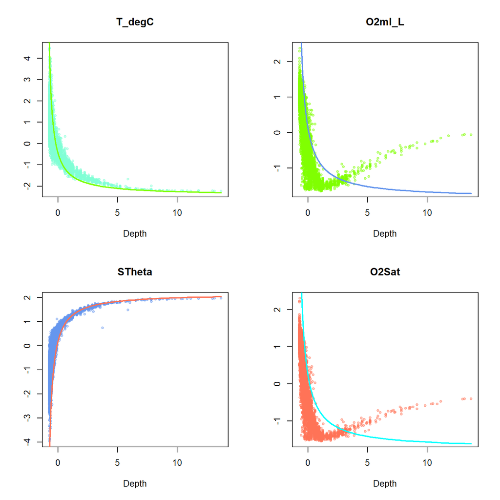

Using this functional forms, I transformed the data to linearize the features, this is the final pairplot:

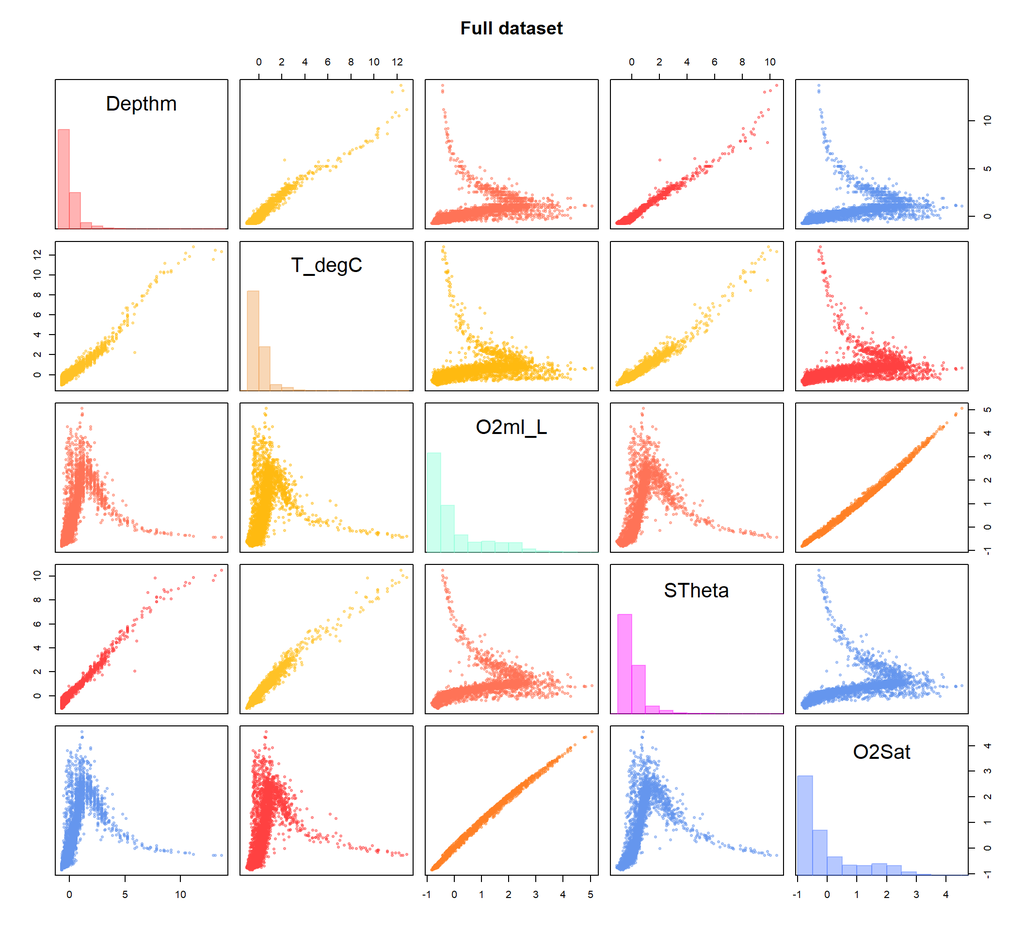

It looks a bit better, but many correlations are still heavily nonlinear. Let’s run the multivariate normal strategy on this new dataset.

### Convergence diagnostics

Here you can see the distribution of the potential scale reduction factor for the 3 set of parameters:

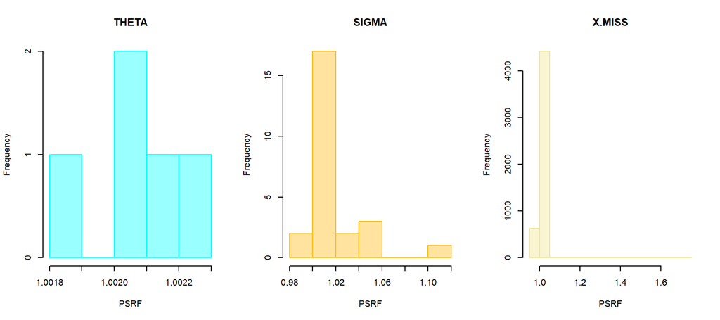

And here you can see the distribution of the geweke statistic for each chain in each set of parameters:

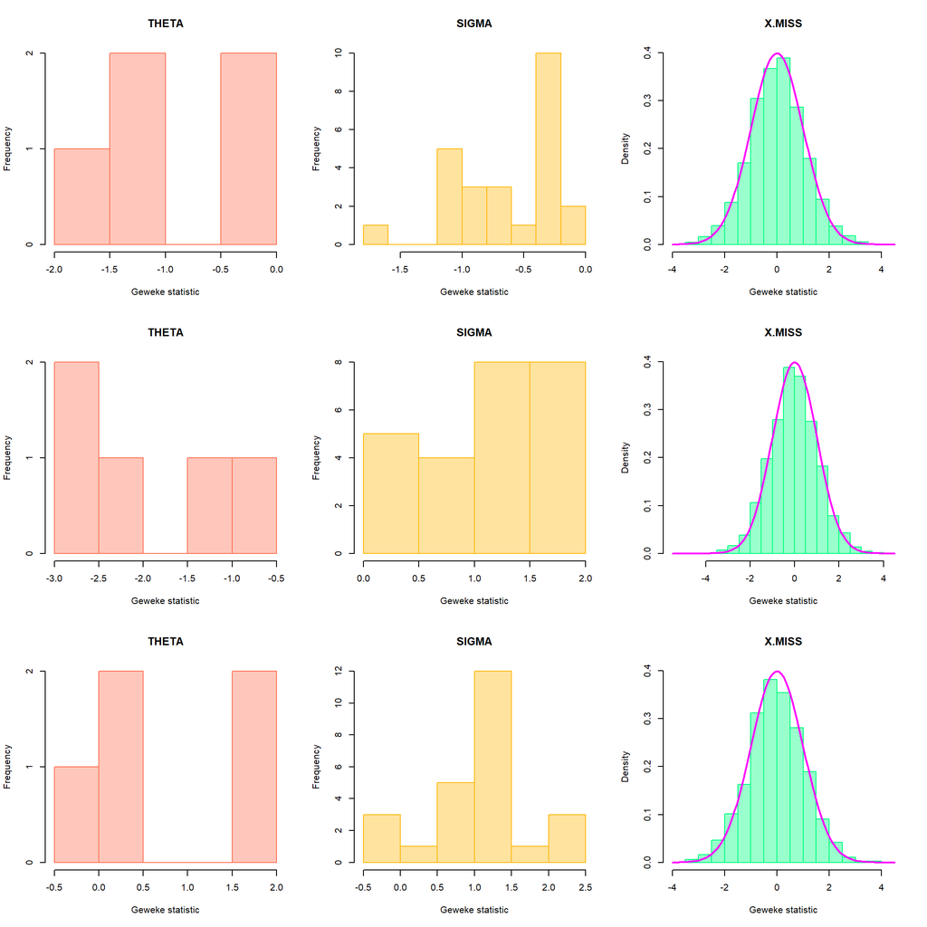

### Performance evaluation

We now want to infer the final imputed values to compare them to the other models. To compute these values we use the average of the values extracted for each of the missing points.

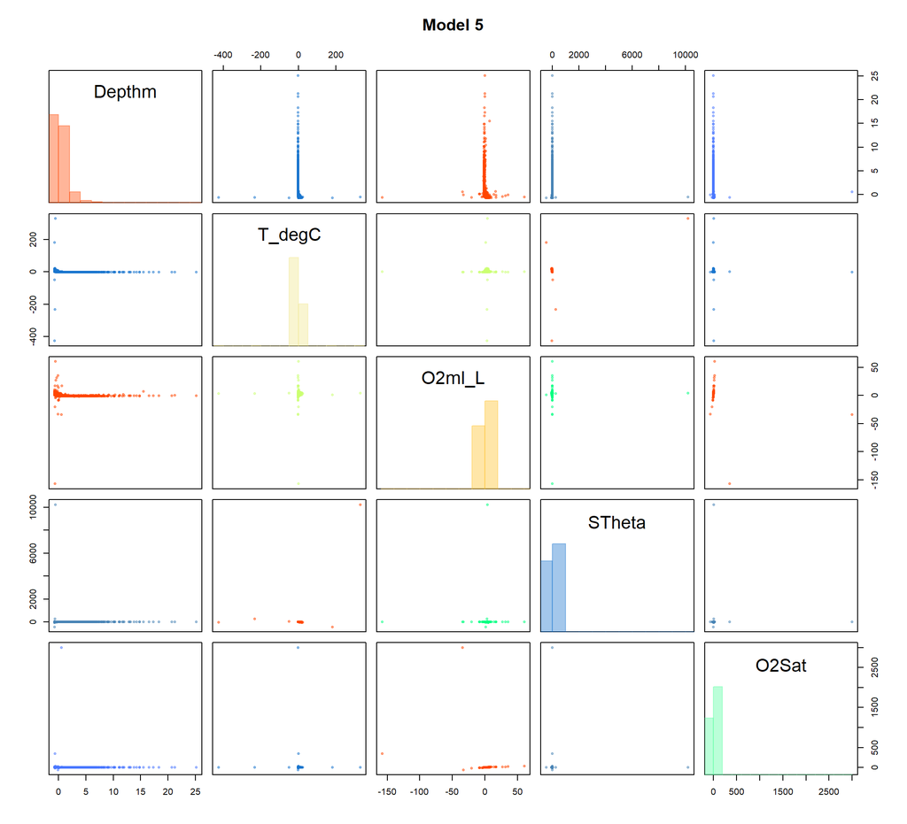

Oddly, many outliers were imputed, so the results are just inadequate. Let’s try to replace the outliers hoping for the best.

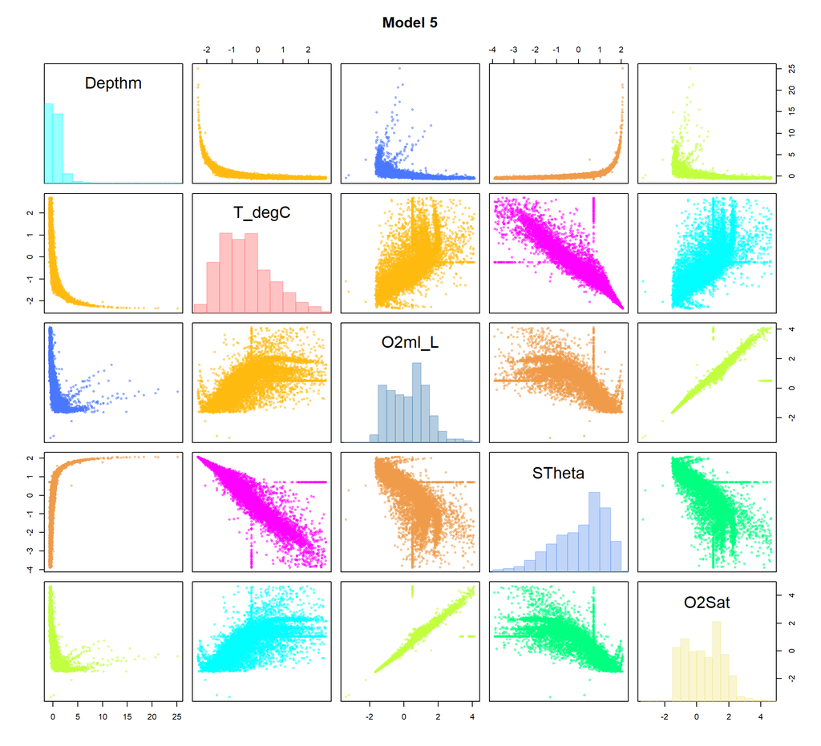

It’s still pretty bad.

Let’s see how it performs with respect to the “true” masked values.

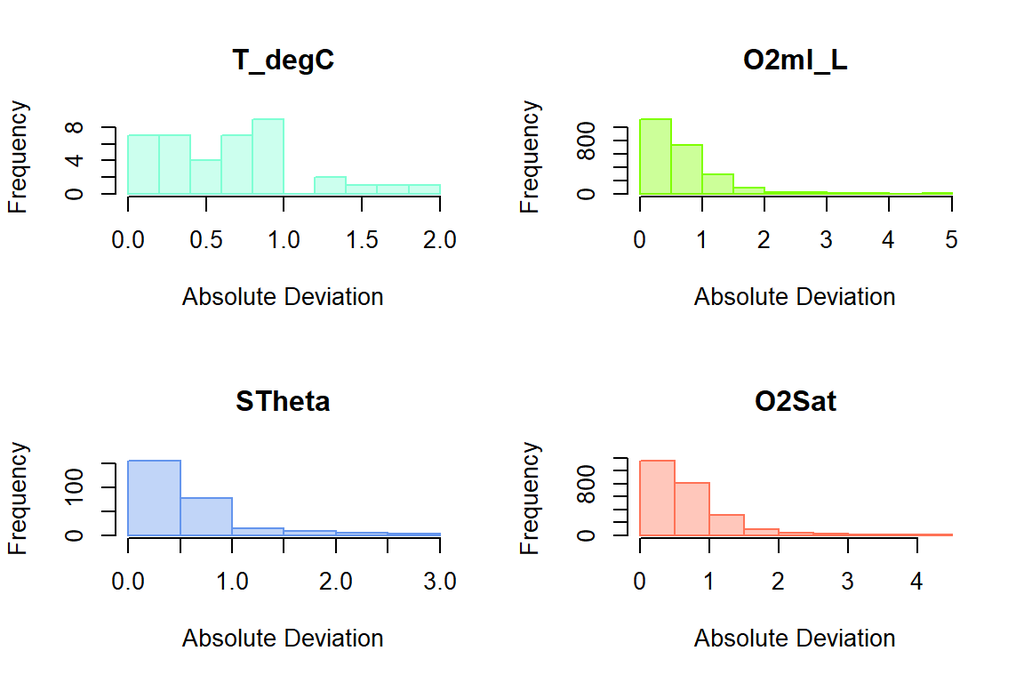

```
## MSE of the imputed data wrt the correct ones:
```

[output not shown]

This imputation method is worse than the frequentist approach in terms of MSE. It’s unexpected and it’s probably due to an error or to some numerical instability due to the $\frac1x$ transform.